# Simple Emax model fit with Stan

Kenta Yoshida

2026-06-12

```r
library(rstanemax)
library(dplyr)
library(ggplot2)
set.seed(12345)
```

This vignette provide an overview of the workflow of Emax model analysis using this package.

# Typical workflow

## Model run with `stan_emax` function

`stan_emax()` is the main function of this package to perform Emax model analysis on the data. This function requires minimum two input arguments - `formula` and `data`. In the `formula` argument, you will specify which columns of `data` will be used as exposure and response data, in a format similar to `stats::lm()` function, e.g. `response ~ exposure`.

```r
data(exposure.response.sample)

fit.emax <- stan_emax(response ~ exposure,
  data = exposure.response.sample,
  # the next line is only to make the example go fast enough
  chains = 2, iter = 1000, seed = 12345
)
```

```r
fit.emax
```

```
#> ---- Emax model fit with rstanemax ----
#>
#>        mean se_mean    sd  2.5%   25%   50%   75%  97.5%  n_eff Rhat
#> emax  92.05    0.22  6.04 80.16 87.90 92.15 96.12 103.97 758.47    1
#> e0     5.68    0.18  4.79 -4.17  2.56  5.61  8.91  15.17 736.90    1
#> ec50  76.28    0.83 22.46 42.90 60.92 72.93 87.67 125.76 738.39    1
#> gamma  1.00     NaN  0.00  1.00  1.00  1.00  1.00   1.00    NaN  NaN
#> sigma 16.57    0.06  1.65 13.71 15.44 16.44 17.68  20.03 654.58    1
#>
#> * Use `extract_stanfit()` function to extract raw stanfit object
#> * Use `extract_param()` function to extract posterior draws of key parameters
#> * Use `plot()` function to visualize model fit
#> * Use `posterior_predict()` or `posterior_predict_quantile()` function to get
#>   raw predictions or make predictions on new data
#> * Use `extract_obs_mod_frame()` function to extract raw data
#>   in a processed format (useful for plotting)
```

`plot()` function shows the estimated Emax model curve with 95% credible intervals of parameters.

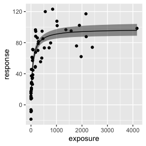

```r
plot(fit.emax)
```

Output of `plot()` function (for `stanemax` object) is a `ggplot` object, so you can apply additional settings as you would do in `ggplot2`.  
Here is an example of using log scale for x axis (note that exposure == 0 is hanging at the very left, making the curve a bit weird).

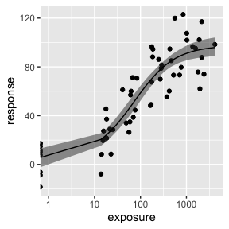

```r
plot(fit.emax) + scale_x_log10() + expand_limits(x = 1)
```

Raw output from `rstan` is stored in the output variable, and you can access it with `extract_stanfit()` function.

```r
class(extract_stanfit(fit.emax))
```

```
#> [1] "stanfit"
#> attr(,"package")
#> [1] "rstan"
```

## Prediction of response with new exposure data

`posterior_predict()` function allows users to predict the response using new exposure data. If `newdata` is not provided, the function returns the prediction on the exposures in original data. The default output is a matrix of posterior predictions, but you can also specify “dataframe” or “tibble” that contain posterior predictions in a long format. See help of `rstanemax::posterior_predict()` for the description of two predictions, `respHat` and `response`.

```r
response.pred <- posterior_predict(fit.emax, newdata = c(0, 100, 1000), returnType = "tibble")
response.pred %>% select(mcmcid, exposure, respHat, response)
```

```
#> # A tibble: 3,000 × 4
#>    mcmcid exposure   respHat response
#>     <int>    <dbl> <dbl[1d]>    <dbl>
#>  1      1        0      5.34     7.51
#>  2      1      100     65.7     92.8
#>  3      1     1000     93.8     86.8
#>  4      2        0      8.20    -5.50
#>  5      2      100     50.7     47.3
#>  6      2     1000     90.3     83.1
#>  7      3        0      1.41   -14.3
#>  8      3      100     60.7     60.8
#>  9      3     1000     92.7     85.5
#> 10      4        0      4.98    40.1
#> # ℹ 2,990 more rows
```

You can also get quantiles of predictions with `posterior_predict_quantile()` function.

```r
resp.pred.quantile <- posterior_predict_quantile(fit.emax, newdata = seq(0, 5000, by = 100))
resp.pred.quantile
```

```
#> # A tibble: 51 × 11
#>    exposure covemax covec50 cove0 Covariates ci_low ci_med ci_high pi_low pi_med
#>       <dbl> <fct>   <fct>   <fct> <chr>       <dbl>  <dbl>   <dbl>  <dbl>  <dbl>
#>  1        0 1       1       1     ""          -2.29   5.61    13.1  -24.2   5.75
#>  2      100 1       1       1     ""          52.2   58.7     64.5   30.0  58.3
#>  3      200 1       1       1     ""          67.6   72.7     77.4   46.5  72.8
#>  4      300 1       1       1     ""          74.5   79.4     83.8   51.4  78.9
#>  5      400 1       1       1     ""          78.5   83.1     87.7   57.1  84.0
#>  6      500 1       1       1     ""          80.8   85.6     90.6   59.9  87.3
#>  7      600 1       1       1     ""          82.2   87.4     92.6   60.6  87.3
#>  8      700 1       1       1     ""          83.4   88.6     94.2   61.0  88.5
#>  9      800 1       1       1     ""          84.2   89.6     95.3   61.9  88.8
#> 10      900 1       1       1     ""          84.8   90.4     96.4   63.1  91.2
#> # ℹ 41 more rows
#> # ℹ 1 more variable: pi_high <dbl>
```

Input data can be obtained in a same format with `extract_obs_mod_frame()` function.

```r
obs.formatted <- extract_obs_mod_frame(fit.emax)
```

These are particularly useful when you want to plot the estimated Emax curve.

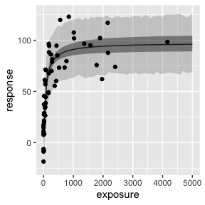

```r
ggplot(resp.pred.quantile, aes(exposure, ci_med)) +
  geom_line() +
  geom_ribbon(aes(ymin = ci_low, ymax = ci_high), alpha = .5) +
  geom_ribbon(aes(ymin = pi_low, ymax = pi_high), alpha = .2) +
  geom_point(
    data = obs.formatted,
    aes(y = response)
  ) +
  labs(y = "response")
```

Posterior draws of Emax model parameters can be extracted with `extract_param()` function.

```r
posterior.fit.emax <- extract_param(fit.emax)
posterior.fit.emax
```

```
#> # A tibble: 1,000 × 6
#>    mcmcid  emax    e0  ec50     gamma     sigma
#>     <int> <dbl> <dbl> <dbl> <dbl[1d]> <dbl[1d]>
#>  1      1  93.3  5.34  54.7         1      16.8
#>  2      2  91.6  8.20 115.          1      16.5
#>  3      3  97.2  1.41  63.7         1      15.2
#>  4      4  83.3  4.98  47.2         1      16.1
#>  5      5  94.2  2.13  63.9         1      14.1
#>  6      6  86.7  9.15  70.1         1      15.0
#>  7      7 104.  -5.00  54.1         1      15.5
#>  8      8  96.5  7.98  93.0         1      18.0
#>  9      9  94.5  3.74  98.4         1      16.0
#> 10     10  94.5  5.91  94.1         1      17.8
#> # ℹ 990 more rows
```

# Fix parameter values in Emax model

You can fix parameter values in Emax model for Emax, E0 and/or gamma (Hill coefficient). See help of `stan_emax()` for the details. The default is to fix gamma at 1 and to estimate Emax and E0 from data.

Below is the example of estimating gamma from data.

```r
data(exposure.response.sample)

fit.emax.sigmoidal <- stan_emax(response ~ exposure,
  data = exposure.response.sample,
  gamma.fix = NULL,
  # the next line is only to make the example go fast enough
  chains = 2, iter = 1000, seed = 12345
)
```

```r
fit.emax.sigmoidal
```

```
#> ---- Emax model fit with rstanemax ----
#>
#>        mean se_mean    sd  2.5%   25%   50%   75%  97.5%  n_eff Rhat
#> emax  88.81    0.51  9.35 73.14 82.60 87.95 93.93 109.34 337.17    1
#> e0     6.98    0.22  4.86 -2.89  3.84  7.05 10.28  16.50 502.11    1
#> ec50  75.20    1.64 26.84 43.68 58.93 69.93 83.93 138.88 267.26    1
#> gamma  1.19    0.02  0.34  0.65  0.96  1.16  1.36   2.03 365.20    1
#> sigma 16.69    0.07  1.67 13.80 15.45 16.58 17.77  20.26 661.42    1
#>
#> * Use `extract_stanfit()` function to extract raw stanfit object
#> * Use `extract_param()` function to extract posterior draws of key parameters
#> * Use `plot()` function to visualize model fit
#> * Use `posterior_predict()` or `posterior_predict_quantile()` function to get
#>   raw predictions or make predictions on new data
#> * Use `extract_obs_mod_frame()` function to extract raw data
#>   in a processed format (useful for plotting)
```

You can compare the difference of posterior predictions between two models (in this case they are very close to each other):

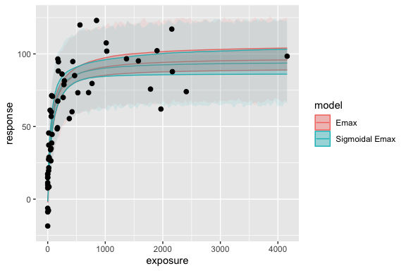

```r
exposure_pred <- seq(min(exposure.response.sample$exposure),
  max(exposure.response.sample$exposure),
  length.out = 100
)

pred1 <-
  posterior_predict_quantile(fit.emax, exposure_pred) %>%
  mutate(model = "Emax")
pred2 <-
  posterior_predict_quantile(fit.emax.sigmoidal, exposure_pred) %>%
  mutate(model = "Sigmoidal Emax")

pred <- bind_rows(pred1, pred2)


ggplot(pred, aes(exposure, ci_med, color = model, fill = model)) +
  geom_line() +
  geom_ribbon(aes(ymin = ci_low, ymax = ci_high), alpha = .3) +
  geom_ribbon(aes(ymin = pi_low, ymax = pi_high), alpha = .1, color = NA) +
  geom_point(
    data = exposure.response.sample, aes(exposure, response),
    color = "black", fill = NA, size = 2
  ) +
  labs(y = "response")
```

# Set covariates

You can specify categorical covariates for Emax, EC50, and E0. See help of `stan_emax()` for the details.

```r
data(exposure.response.sample.with.cov)

test.data <-
  mutate(exposure.response.sample.with.cov,
    SEX = ifelse(cov2 == "B0", "MALE", "FEMALE")
  )

fit.cov <- stan_emax(
  formula = resp ~ conc, data = test.data,
  param.cov = list(emax = "SEX"),
  # the next line is only to make the example go fast enough
  chains = 2, iter = 1000, seed = 12345
)
```

```r
fit.cov
```

```
#> ---- Emax model fit with rstanemax ----
#>
#>                mean se_mean    sd  2.5%   25%    50%    75%  97.5%  n_eff Rhat
#> emax[FEMALE]  81.25    0.19  4.22 73.02 78.38  81.15  84.05  89.15 510.40 1.00
#> emax[MALE]    87.36    0.23  5.15 77.35 83.76  87.46  90.82  97.83 519.75 1.00
#> e0            15.17    0.11  2.43 10.29 13.70  15.27  16.70  19.66 504.33 1.00
#> ec50         106.13    0.86 21.42 67.85 91.97 104.61 118.72 155.08 617.15 1.01
#> gamma          1.00     NaN  0.00  1.00  1.00   1.00   1.00   1.00    NaN  NaN
#> sigma         10.56    0.04  1.06  8.81  9.77  10.47  11.28  12.92 749.70 1.00
#>
#> * Use `extract_stanfit()` function to extract raw stanfit object
#> * Use `extract_param()` function to extract posterior draws of key parameters
#> * Use `plot()` function to visualize model fit
#> * Use `posterior_predict()` or `posterior_predict_quantile()` function to get
#>   raw predictions or make predictions on new data
#> * Use `extract_obs_mod_frame()` function to extract raw data
#>   in a processed format (useful for plotting)
```

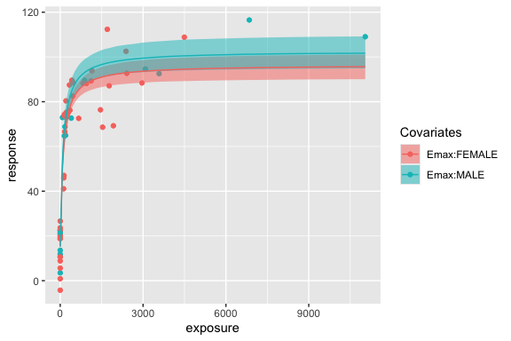

```r
plot(fit.cov)
```

You can extract MCMC samples from raw stanfit and evaluate differences between groups.

```r
fit.cov.posterior <-
  extract_param(fit.cov)

emax.posterior <-
  fit.cov.posterior %>%
  select(mcmcid, SEX, emax) %>%
  tidyr::pivot_wider(names_from = SEX, values_from = emax) %>%
  mutate(delta = FEMALE - MALE)

ggplot2::qplot(delta, data = emax.posterior, bins = 30) +
  ggplot2::labs(x = "emax[FEMALE] - emax[MALE]")
# Credible interval of delta
quantile(emax.posterior$delta, probs = c(0.025, 0.05, 0.5, 0.95, 0.975))
```

```
#>       2.5%         5%        50%        95%      97.5%
#> -14.643119 -13.342322  -6.111658   1.025680   2.219764
```

```r
# Posterior probability of emax[FEMALE] < emax[MALE]
sum(emax.posterior$delta < 0) / nrow(emax.posterior)
```

```
#> [1] 0.914
```

[figure not shown]